# Punto 2: Verificación empírica de estimadores para distribución uniforme

2025-04-30

## Introducción

En este documento se realiza la verificación empírica de tres estimadores diferentes para el parámetro θ de una distribución uniforme U(0,θ). Se comparan sus propiedades estadísticas como el sesgo y la varianza, contrastando los resultados empíricos con los valores teóricos esperados.

## Configuración inicial

Definimos los parámetros de simulación:

```r
set.seed(123)  # Para reproducibilidad
theta <- 8     # Valor real del parámetro theta
n <- 100       # Tamaño de cada muestra
M <- 10000     # Número de simulaciones

# Inicializar vectores para almacenar los estimadores
theta1 <- numeric(M) # Estimador por método de momentos
theta2 <- numeric(M) # Estimador de máxima verosimilitud
theta3 <- numeric(M) # Estimador basado en el mínimo
```

## Simulaciones

Generamos M muestras y calculamos los tres estimadores para cada una:

```r
for (i in 1:M) {
  muestra <- runif(n, min = 0, max = theta)

  # Estimadores
  theta1[i] <- 2 * mean(muestra)                     # Momentos
  theta2[i] <- max(muestra) * (n + 1) / n            # Máxima verosimilitud (corregido)
  theta3[i] <- min(muestra) * (n + 1)                # Basado en mínimo
}
```

## Cálculo de Sesgo y Varianza Empírica

```r
# Sesgos
sesgo_theta1 <- mean(theta1) - theta
sesgo_theta2 <- mean(theta2) - theta
sesgo_theta3 <- mean(theta3) - theta

# Varianzas
varianza_theta1 <- var(theta1)
varianza_theta2 <- var(theta2)
varianza_theta3 <- var(theta3)

# Resultados en forma de tabla
resultados_empiricos <- data.frame(
  Estimador = c("θ1 (momentos)", "θ2 (máx. verosimilitud)", "θ3 (mínimo)"),
  Sesgo = round(c(sesgo_theta1, sesgo_theta2, sesgo_theta3), 4),
  Varianza = round(c(varianza_theta1, varianza_theta2, varianza_theta3), 4)
)

knitr::kable(resultados_empiricos, caption = "Resultados empíricos de los estimadores")
```

Resultados empíricos de los estimadores

| Estimador | Sesgo | Varianza |
| --- | --- | --- |
| θ1 (momentos) | -0.0075 | 0.2097 |
| θ2 (máx. verosimilitud) | -0.0008 | 0.0064 |
| θ3 (mínimo) | -0.0524 | 61.8238 |

## Valores Teóricos

Calculamos los valores teóricos esperados para la varianza de cada estimador:

```r
var_teorica_theta1 <- (theta^2) / (3 * n)
var_teorica_theta2 <- (theta^2) / ((n + 1)^2 * (n + 2)) * n^2  # Fórmula corregida
var_teorica_theta3 <- (n * theta^2) / ((n + 1)^2 * (n + 2))    # Fórmula revisada

resultados_teoricos <- data.frame(
  Estimador = c("θ1 (momentos)", "θ2 (máx. verosimilitud)", "θ3 (mínimo)"),
  `Varianza Teórica` = round(c(var_teorica_theta1, var_teorica_theta2, var_teorica_theta3), 4)
)

knitr::kable(resultados_teoricos, caption = "Valores teóricos de varianza")
```

Valores teóricos de varianza

| Estimador | Varianza.Teórica |
| --- | --- |
| θ1 (momentos) | 0.2133 |
| θ2 (máx. verosimilitud) | 0.6151 |
| θ3 (mínimo) | 0.0062 |

## Análisis Gráfico

### Histogramas de los Estimadores

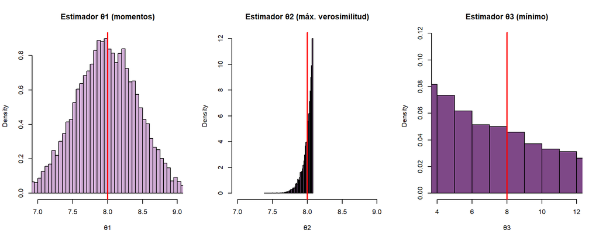

```r
par(mfrow = c(1, 3))

hist(theta1, main = "Estimador θ1 (momentos)",
     xlab = "θ1", col = "#d2aed7", breaks = 50,
     xlim = c(7, 9), probability = TRUE)
abline(v = theta, col = "red", lwd = 2)

hist(theta2, main = "Estimador θ2 (máx. verosimilitud)",
     xlab = "θ2", col = "#b07cb8", breaks = 50,
     xlim = c(7, 9), probability = TRUE)
abline(v = theta, col = "red", lwd = 2)

hist(theta3, main = "Estimador θ3 (mínimo)",
     xlab = "θ3", col = "#7e4887", breaks = 50,
     xlim = c(4, 12), probability = TRUE)
abline(v = theta, col = "red", lwd = 2)
```